# A review of bioinformatic pipeline frameworks

## Configuration frameworks

Many pipeline frameworks dispense with inline scripting code and instead use a configuration-based, rather than convention-based, means of describing tasks. Pegasus [9] is a National Science Foundation (NSF)-funded workflow system originally designed for the physical sciences. Like all configuration-based frameworks, Pegasus is explicit—it does not implicitly infer how to produce targets but instead requires a fixed XML file that describes individual job run instances and their dependencies ([Figure 6](https://www.ncbi.nlm.nih.gov/pmc/articles/PMC5429012/figure/bbw020-F6/)).

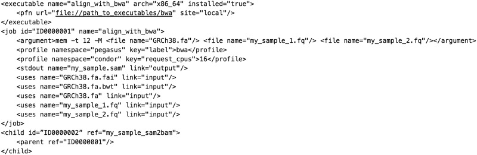

A Pegasus DAX (Directed Acyclic Graph in XML). A subsequent step to alignment has been included to show that a Pegasus task relies on explicit job IDs to identify its antecedents rather than a filename pattern to identify its dependencies. Pegasus has no built-in system of variable injection, but includes APIs to produce DAX files.

## Class-based frameworks

Some high-performance workflow languages are implemented in a class-based pure language manner. Although these may resemble DSL-based frameworks superficially, class-based implementations are often closely bound to an existing code library rather than various executables. Class-based pipelines often contain many thousands of lines of code implementing domain logic. Genome Analysis Toolkit (GATK) [10] is a large Java library for variant analysis, and Queue is a GATK-integrated Scala framework that provides abstract classes for implementing pipelines. Luigi (https://github.com/spotify/luigi) and Toil (https://github.com/bd2kgenomics/toil) are pure-Python frameworks that are not bound to any bioinformatics codebase, but offer explicit Application Programming Interfaces (APIs) for defining task dependencies from within task methods. Luigi places particular emphasis on scheduled execution, monitoring, visualization and the implicit dependency resolution of tasks. Toil offers a strong focus on cloud execution.

Many existing implementations of bioinformatics software tend to work with large ‘monolithic’ disk-based files, which impedes the ability of work tasks to be efficiently farmed out to individual cores or nodes in a cluster, or to ephemeral machine instances in the cloud. Efforts such as Big Data Genomics (http://bdgenomics.org) aim to make common data formats ‘splittable’ for use with Hadoop and Spark-based scalable distributed computing frameworks. These efforts will likely also require the use of new or existing class-based pipelines for tasks to be tightly coupled to individual data structures within the library, allowing a high level of granularity in terms of the concurrent processing of data.

## Server workbenches

For existing tools that have an existing component plug-in, using Taverna is an easy solution for end-users. Creating a new plug-in requires an in-depth knowledge of the XML-based API and exact specifications of acceptable input filetypes, parameter values, resource management and exception behavior. The onus is entirely on the developer to provide a means for new tools to exist in the Taverna ecosystem. Adding a new executable to Galaxy often requires only 20 lines of configuration code, but Galaxy wrappers can be less robust than those in Taverna, which requires slightly more familiarity with each tool on the part of end-users to implement.

## Cloud workbenches and APIs

Cloud computing, defined here as the on-demand rent of virtualized computing infrastructure from remote managed data centers, offers an attractive scalable option for collaborative multi-institutional research in terms of ‘bringing the tools to the data’. Although subscription and compute costs are decreasing, the speed of file transfer over the Internet to the cloud remains an issue for these platforms. While all of the aforementioned pipelines can be installed on cloud infrastructure [13], cloud workbenches offer a layer of abstraction that simplifies the complex process of provisioning servers.

Commercial workbenches, such as DNAnexus (http://dnanexus.com), SevenBridges (http://sbgenomics.com) and Illumina’s BaseSpace (http://basespace.illumina.com), leverage the scalability of cloud computing to offer high performance while offering development and user experiences comparable with local server-based open source workbenches. These providers also support APIs that allow users to launch automated large batch analyses without using a Web interface.

Next-generation cloud-based open source workbenches, such as Curoverse’s Arvados (https://curoverse.com) and the iPlant Collaborative’s Agave [14], largely dispense with the Web GUI as a primary design tool and instead are built from the ground up as APIs designed to enable the migration of local analyses to the cloud for collaborative research.

## Choosing a pipeline framework

Although there is no formal study of bioinformatics pipeline users specifically, a previous survey (https://github.com/michaelbarton/bioinformatics-career-survey) suggests the audience for bioinformatics development is evenly mixed between those with biological and computer science backgrounds, and large and small institutions. The choice of framework should be informed both by the demands of developing the pipeline and the requirements of those using it, even if the developers and end-users are the same people. The use of pipeline frameworks is intimately tied to reproducible computational research [15], as *ad hoc* analyses are not likely to be implemented in a pipeline. Reusable pipelines that can be run in the cloud are often preferable in terms of reproducible research and the type of collaborative ‘big science’ popular in modern sequencing studies.

Choosing between an implicit or explicit syntax is largely a question of personal preference. To developers unfamiliar with Make rule syntax, arranging a series of implicit wildcard rules and trusting the engine to infer a dependency tree can seem unintuitive, but this idiomatic style offers a high level of convenience for integrating executable tools.

Convention-based frameworks tend to encourage a high level of internal business logic. They also allow polished deliverables (Web sites, PDF reports) to be easily generated from the underlying data. At the same time, pipelines that ‘think on their feet’ would seem inherently less reproducible when compared with configuration-based pipelines that demand a paper trail, but often the latter simply forces developers to write dynamic tools to generate static configurations. Because they are ‘set in stone’, configuration-based pipelines often enable cluster schedulers to consume an entire work plan in entirety instead of receiving tasks in a piecemeal fashion, allowing the scheduler to better anticipate load and allocate both memory and compute resources.

Workbenches and class-based frameworks can be considered heavyweight. There are costs in terms of flexibility and ease of development associated with making a pipeline accessible or fast. Integrating new tools into workbenches clearly increases their audience, but, ironically, the developers who are most capable of developing plug-ins for workbenches are the least likely to use them. Class-based frameworks offer a high level of performance, but like workbenches, require highly skilled developers to build and maintain, and performance improvements are not guaranteed to justify additional development time. The transition to high-performance computing (HPC) frameworks will likely favor class-based pipeline frameworks in the future, although this will severely limit the number of developers who will be able to contribute to these pipelines, owing to their inherent complexity of HPC development compared with DSLs. A recent survey of institutions using bioinformatics pipelines [16] found that virtually every participant anticipated further use of HPC-enabled pipelines in the future and had struggled with issues of reproducibility and data provenance. These issues require intense attention to implementing highly customized solutions that do not lend themselves to lightweight pipelines.

For those laboratories that neither serve a large number of pure biologists who demand a workbench interface nor require the high level of performance that class-based pipelines offer, a clear choice is not so obvious. One heuristic for choosing a framework to consider is ‘return on investment’. Laboratories that conduct large-scale, highly repetitive research requiring a high degree of data provenance and versioning may benefit from configuration-based pipelines. Laboratories doing exploratory proofs-of-concept would see little reason to use more heavyweight frameworks—explicit DSL-based pipelines are adequate.

Finally, most laboratories, especially those without access to internal HPC resources, should consider cloud-based workbenches and APIs. These offer many of the features of server-based frameworks, with the added bonus of unlimited scalability and collaborative research opportunities, albeit incurring direct costs.

Although this review is not intended to be an exhaustive list of pipeline frameworks, such lists do exist (e.g. https://github.com/pditommaso/awesome-pipeline). For laboratories relying solely on scripts, the choice of a framework, especially one to accommodate new custom tools, may seem overwhelming and irreversible, but all frameworks use the parameterization of inputs, outputs and tool descriptors. Once a script-based pipeline is implemented in one framework, transitioning to a different one is relatively simple should priorities change.

### Key Points

- Key pipeline concepts of dependency and reentrancy were introduced by Make.
- Pipelines are best distinguished not by features but by design philosophy.
- Modern bioinformatic frameworks use a convention, configuration or class-based design paradigm and use an explicit or implicit syntax.
- Workbenches and class-based frameworks offer ease of use and performance, respectively, but require additional investment in time and expertise to integrate new tools.
- Cloud-based platforms offer scalability and collaborative research advantages.
- Developers choosing a pipeline framework should consider the return on investment when considering more heavyweight options.

## Acknowledgements

I thank Deanne Taylor, Chaomei Chen, and Jane Greenberg for their support. I also thank the anonymous reviewers for their helpful comments and suggestions.

### Funding

This work is supported by The Children’s Hospital of Philadelphia.

## Notes

**Jeremy Leipzig** is a bioinformatics software developer at The Children’s Hospital of Philadelphia. He received his MS in Computer Science from North Carolina State University. He is pursuing a PhD in Information Studies at Drexel University.

## References

1. Fisch KM, Meißner T, Gioia L, et al. Omics pipe: a community-based framework for reproducible multi-omics data analysis. Bioinformatics 2015;31: 1724–8. [[PMC free article](https://www.ncbi.nlm.nih.gov/pmc/articles/PMC4443682/)] [[PubMed](https://pubmed.ncbi.nlm.nih.gov/25637560)] [Google Scholar]

2. Sussman GJ. Building robust systems an essay. Citeseer 2007;113:1324. [[Google Scholar](https://scholar.google.com/scholar_lookup?journal=Citeseer&title=Building+robust+systems+an+essay&author=GJ.+Sussman&volume=113&publication_year=2007&pages=1324&)]

3. Stallman RM, McGrath R. GNU Make: a Program for Directed Recompilation, Version 3.79.1. Boston: GNU Press, 2002.

4. Li H. Aligning sequence reads, clone sequences and assembly contigs with BWA-MEM. arXiv 2013;1303.3997v2. [[Google Scholar](https://scholar.google.com/scholar_lookup?journal=arXiv&title=Aligning+sequence+reads,+clone+sequences+and+assembly+contigs+with+BWA-MEM&author=H.+Li&publication_year=2013&)]

5. Köster J, Rahmann S.. Snakemake–a scalable bioinformatics workflow engine. Bioinformatics 2012;28:2520–2. [[PubMed](https://pubmed.ncbi.nlm.nih.gov/22908215)] [Google Scholar]

6. Cingolani P, Sladek R, Blanchette M.. BigDataScript: a scripting language for data pipelines. Bioinformatics 2015;31:10–16. [[PMC free article](https://www.ncbi.nlm.nih.gov/pmc/articles/PMC4271142/)] [[PubMed](https://pubmed.ncbi.nlm.nih.gov/25189778)] [Google Scholar]

7. Goodstadt L. Ruffus: a lightweight Python library for computational pipelines. Bioinformatics 2010;26:2778–9. [[PubMed](https://pubmed.ncbi.nlm.nih.gov/20847218)] [Google Scholar]

8. Sadedin SP, Pope B, Oshlack A.. Bpipe: a tool for running and managing bioinformatics pipelines. Bioinformatics 2012;28:1525–6. [[PubMed](https://pubmed.ncbi.nlm.nih.gov/22500002)] [Google Scholar]

9. Deelman E, Singh G, Su M-H, et al. Pegasus: a framework for mapping complex scientific workflows onto distributed systems. Sci Program 2005;13:219–37. [Google Scholar]

10. DePristo MA, Banks E, Poplin R, et al. A framework for variation discovery and genotyping using next-generation DNA sequencing data. Nat Rev Clin Oncol 2011;43:491–8. [[PMC free article](https://www.ncbi.nlm.nih.gov/pmc/articles/PMC3083463/)] [[PubMed](https://pubmed.ncbi.nlm.nih.gov/21478889)] [Google Scholar]

11. Goecks J, Nekrutenko A, Taylor J, et al. Galaxy: a comprehensive approach for supporting accessible, reproducible, and transparent computational research in the life sciences. Genome Biol 2010;11:R86. [[PMC free article](https://www.ncbi.nlm.nih.gov/pmc/articles/PMC2945788/)] [[PubMed](https://pubmed.ncbi.nlm.nih.gov/20738864)] [Google Scholar]

12. Wolstencroft K, Haines R, Fellows D, et al. The Taverna workflow suite: designing and executing workflows of Web Services on the desktop, web or in the cloud. Nucleic Acids Res 2013;41:W557–61. [[PMC free article](https://www.ncbi.nlm.nih.gov/pmc/articles/PMC3692062/)] [[PubMed](https://pubmed.ncbi.nlm.nih.gov/23640334)] [Google Scholar]

13. Liu B, Madduri RK, Sotomayor B, et al. Cloud-based bioinformatics workflow platform for large-scale next-generation sequencing analyses. J Biomed Inform 2014;49:119–33. [[PMC free article](https://www.ncbi.nlm.nih.gov/pmc/articles/PMC4203338/)] [[PubMed](https://pubmed.ncbi.nlm.nih.gov/24462600)] [Google Scholar]

14. Dooley R, Vaughn M, Stanzione D, et al. Software-as-a-service: the iPlant foundation API. 5th IEEE Workshop on Many-Task Computing on Grids and Supercomputers (MTAGS), 2012. Salt Lake City, Utah, USA.

15. Hurley DG, Budden DM, Crampin EJ.. Virtual reference environments: a simple way to make research reproducible. Brief Bioinform 2015;16:901–3. [[PMC free article](https://www.ncbi.nlm.nih.gov/pmc/articles/PMC4570198/)] [[PubMed](https://pubmed.ncbi.nlm.nih.gov/25433467)] [Google Scholar]

16. Spjuth O, Bongcam-Rudloff E, Hernández GC, et al. Experiences with workflows for automating data-intensive bioinformatics. Biol Direct 2015;10:43. [[PMC free article](https://www.ncbi.nlm.nih.gov/pmc/articles/PMC4539931/)] [[PubMed](https://pubmed.ncbi.nlm.nih.gov/26282399)] [Google Scholar]